# Part I - Used Car Data Exploration and Visualizations

## Introduction

### Used Car Data

> This dataset includes information (e.g. Sales_ID, name, year, selling_price, km_driven, Region, State or Province, City, fuel, seller_type, transmission, owner, mileage, engine, max_power, torque, seats, sold) of different types of used cars across the market gathered by a consulting firm based on various market surveys for an automobile company XYZ from India which aspires to enter the Indian used car market.

> The Indian used car market, according to [Mordor Intelligence](https://www.mordorintelligence.com/industry-reports/india-used-car-market) during the forecast period (2022-2027) is projected to grow by 15.1% Compound Annual Growth Rate (CAGR) to reach 74.70 Billion Dollars in 2027 from an estimated value of 32.14 Billion Dollars in 2021. The COVID-19 epidemic hardly affected the sector. The market for used cars is expected to expand significantly as more individuals choose independent mobility and as additional financing alternatives become available.

### Questions for the Data Analysis

> 1. Which variables are significant in predicting the price of a used car?
> 2. How well does those variables describe the price of a car?
> 3. Which brands are selling the most?
> 4. Are there specific locations selling more?
> 5. Which factors are more important in deciding cars' selling price?

## Preliminary Wrangling

```python
# import all packages and set plots to be embedded inline
import numpy as np
import pandas as pd
import matplotlib.pyplot as plt
import seaborn as sb

%matplotlib inline
```

> Load in your dataset and describe its properties through the questions below. Try and motivate your exploration goals through this section.

```python
# Load the dataset
df = pd.read_csv('UserCarData.csv')

# Display the first five rows of the dataframe
df.head()
```

|  | Sales_ID | name | year | selling_price | km_driven | Region | State or Province | City | fuel | seller_type | transmission | owner | mileage | engine | max_power | torque | seats | sold |
| --- | --- | --- | --- | --- | --- | --- | --- | --- | --- | --- | --- | --- | --- | --- | --- | --- | --- | --- |
| 0 | 1 | Maruti | 2014 | 450000 | 145500 | East | District of Columbia | Washington | Diesel | Individual | Manual | First_Owner | 23.40 | 1248 | 74.00 | 190Nm@ 2000rpm | 5 | Y |
| 1 | 2 | Skoda | 2014 | 370000 | 120000 | East | New York | New York City | Diesel | Individual | Manual | Second_Owner | 21.14 | 1498 | 103.52 | 250Nm@ 1500-2500rpm | 5 | Y |
| 2 | 3 | Honda | 2006 | 158000 | 140000 | Central | Illinois | Chicago | Petrol | Individual | Manual | Third_Owner | 17.70 | 1497 | 78.00 | 12.7@ 2,700(kgm@ rpm) | 5 | Y |
| 3 | 4 | Hyundai | 2010 | 225000 | 127000 | Central | Illinois | Chicago | Diesel | Individual | Manual | First_Owner | 23.00 | 1396 | 90.00 | 22.4 kgm at 1750-2750rpm | 5 | Y |
| 4 | 5 | Maruti | 2007 | 130000 | 120000 | East | New York | New York City | Petrol | Individual | Manual | First_Owner | 16.10 | 1298 | 88.20 | 11.5@ 4,500(kgm@ rpm) | 5 | Y |

## Data Wrangling

```python
# Display the dimension (i.e. the total number of rows and columns) of the dataframe
df.shape
```

```
(7906, 18)
```

```python
df.columns
```

```
Index(['Sales_ID', 'name', 'year', 'selling_price', 'km_driven', 'Region',
       'State or Province', 'City', 'fuel', 'seller_type', 'transmission',
       'owner', 'mileage', 'engine', 'max_power', 'torque', 'seats', 'sold'],
      dtype='object')
```

```python
# Display the concise summary of the dataframe including the number of non-null values in each column
df.info()
```

```
<class 'pandas.core.frame.DataFrame'>
RangeIndex: 7906 entries, 0 to 7905
Data columns (total 18 columns):
 #   Column             Non-Null Count  Dtype
---  ------             --------------  -----
 0   Sales_ID           7906 non-null   int64
 1   name               7906 non-null   object
 2   year               7906 non-null   int64
 3   selling_price      7906 non-null   int64
 4   km_driven          7906 non-null   int64
 5   Region             7906 non-null   object
 6   State or Province  7906 non-null   object
 7   City               7906 non-null   object
 8   fuel               7906 non-null   object
 9   seller_type        7906 non-null   object
 10  transmission       7906 non-null   object
 11  owner              7906 non-null   object
 12  mileage            7906 non-null   float64
 13  engine             7906 non-null   int64
 14  max_power          7906 non-null   float64
 15  torque             7906 non-null   object
 16  seats              7906 non-null   int64
 17  sold               7906 non-null   object
dtypes: float64(2), int64(6), object(10)
memory usage: 1.1+ MB
```

```python
# Display the number of unique values in each column
df.nunique()
```

```
Sales_ID             7906
name                   31
year                   27
selling_price         670
km_driven             898
Region                  4
State or Province      49
City                 1310
fuel                    4
seller_type             3
transmission            2
owner                   5
mileage               381
engine                121
max_power             318
torque                441
seats                   9
sold                    2
dtype: int64
```

```python
type(df['torque'][15])
```

```
str
```

```python
# Display useful descriptive statistics for each column of the data
df.describe()
```

|  | Sales_ID | year | selling_price | km_driven | mileage | engine | max_power | seats |
| --- | --- | --- | --- | --- | --- | --- | --- | --- |
| count | 7906.000000 | 7906.000000 | 7.906000e+03 | 7.906000e+03 | 7906.000000 | 7906.000000 | 7906.000000 | 7906.000000 |
| mean | 4070.106248 | 2013.983936 | 6.498137e+05 | 6.918866e+04 | 19.419861 | 1458.708829 | 91.587374 | 5.416393 |
| std | 2345.770159 | 3.863695 | 8.135827e+05 | 5.679230e+04 | 4.036263 | 503.893057 | 35.747216 | 0.959208 |
| min | 1.000000 | 1994.000000 | 2.999900e+04 | 1.000000e+00 | 0.000000 | 624.000000 | 32.800000 | 2.000000 |
| 25% | 2037.250000 | 2012.000000 | 2.700000e+05 | 3.500000e+04 | 16.780000 | 1197.000000 | 68.050000 | 5.000000 |
| 50% | 4076.500000 | 2015.000000 | 4.500000e+05 | 6.000000e+04 | 19.300000 | 1248.000000 | 82.000000 | 5.000000 |
| 75% | 6102.000000 | 2017.000000 | 6.900000e+05 | 9.542500e+04 | 22.320000 | 1582.000000 | 102.000000 | 5.000000 |
| max | 8128.000000 | 2020.000000 | 1.000000e+07 | 2.360457e+06 | 42.000000 | 3604.000000 | 400.000000 | 14.000000 |

### What is the structure of your dataset?

> The dataset has 7906 entries of used cars with 18 features (which are Sales_ID, name, year, selling_price, km_driven, Region, State or Province, City, fuel, seller_type, transmission, owner, mileage, engine, max_power, torque, seats and sold). The data types of the variables consist of 2 floats, 6 integers, and 10 strings.

### What is/are the main feature(s) of interest in your dataset?

> My main features of interest is to determine the variables that are significant in predicting the price of a used car and to investigate the sales of used cars made over the years.

### What features in the dataset do you think will help support your investigation into your feature(s) of interest?

> The features in the dataset that will help support my investigation into my features of interest are the different car variables and the different locations where the sales of used cars were recorded.

## Data Cleaning

```python
# Make a copy of the original data frame
df_clean = df.copy()
```

```python
# define a function to clean the torque column
def parser(item):
    item = item.replace(" ", "")
    item = item.replace(",", "")
    item = item.replace("at","@")
    item = item.replace("n", "")
    item = item.replace("NM", "")
    item = item.replace("KGM", "")
    item = item.replace("Nm(38.7kgm)", "")
    item = item.replace("Nm/2000", "")
    item = item.replace("(11.2)", "")
    item = item.replace("/1900", "")
    item = item.rstrip("rpm")
    item = item.rstrip("(kgm@rpm)")
    items = item.split("@")
    items[0] = items[0].rstrip("Nm")
    items[0] = items[0].rstrip("kgm")
    return "=".join(items[:2])
```

```python
# split the torque into two lists of torque and rotational speed
new_torque = list(map(parser, df['torque']))

torque = list(map(lambda i: i.split("=")[0], new_torque))
rotational_speed = list(map(lambda i: i.split("=")[-1], new_torque))
```

```python
# define a function to extract the maximum rotational speed
def parse(item):
    item = item.replace("1500~", "")
    item = item.replace("RPM", "")
    items = item.split("-")
    items = max(items)
    return items
```

```python
# create new torque and max_RPM columns from the old torque
max_rotation = list(map(parse, rotational_speed))

df_clean["torque"] = torque
df_clean["max_RPM"] = max_rotation
```

```python
# rename columns with inappropriate column labels
df_clean.rename(columns={"Sales_ID":"sales_ID", "Region":"region", "State or Province":"state", "City":"city"}, inplace=True)
```

```python
# display random 10 entries
df_clean.sample(10)
```

|  | sales_ID | name | year | selling_price | km_driven | region | state | city | fuel | seller_type | transmission | owner | mileage | engine | max_power | torque | seats | sold | max_RPM |
| --- | --- | --- | --- | --- | --- | --- | --- | --- | --- | --- | --- | --- | --- | --- | --- | --- | --- | --- | --- |
| 5681 | 5849 | Hyundai | 2016 | 700000 | 100000 | Central | Illinois | Lansing | Diesel | Individual | Manual | First_Owner | 22.54 | 1396 | 88.73 | 219.7 | 5 | N | 2750 |
| 696 | 717 | Honda | 2007 | 325000 | 70000 | Central | Illinois | Chicago | Petrol | Individual | Automatic | Second_Owner | 10.10 | 2354 | 152.00 | 215 | 5 | Y | 3600 |
| 5645 | 5810 | Toyota | 2013 | 625000 | 100000 | Central | Illinois | Evanston | Diesel | Individual | Manual | Second_Owner | 12.99 | 2494 | 100.57 | 200 | 7 | N | 3400 |
| 1056 | 1088 | Maruti | 2019 | 650000 | 5621 | South | Florida | Seminole | Petrol | Trustmark_Dealer | Automatic | First_Owner | 22.00 | 1197 | 81.80 | 113 | 5 | Y | 4200 |
| 632 | 652 | Toyota | 2016 | 2000000 | 68089 | West | Washington | Seattle | Petrol | Trustmark_Dealer | Automatic | First_Owner | 19.16 | 2494 | 157.70 | 213 | 5 | Y | 4500 |
| 6414 | 6597 | Mahindra | 2012 | 900000 | 100000 | Central | Michigan | Inkster | Diesel | Individual | Manual | First_Owner | 15.10 | 2179 | 140.00 | 330 | 7 | N | 2800 |
| 716 | 738 | Hyundai | 2018 | 531000 | 20000 | Central | Illinois | Chicago | Petrol | Individual | Automatic | First_Owner | 18.90 | 1197 | 81.86 | 113.75 | 5 | Y | 4000 |
| 4111 | 4235 | Jaguar | 2017 | 2711000 | 9000 | South | Tennessee | Bartlett | Diesel | Dealer | Automatic | First_Owner | 13.60 | 1999 | 177.00 | 430 | 5 | N | 2500 |
| 7342 | 7554 | Chevrolet | 2016 | 750000 | 67600 | East | Ohio | Medina | Diesel | Individual | Automatic | First_Owner | 14.81 | 1998 | 163.70 | 360 | 5 | N | 2000 |
| 5283 | 5434 | Tata | 2017 | 450000 | 80000 | South | Georgia | La Grange | Diesel | Individual | Manual | First_Owner | 27.28 | 1047 | 69.00 | 140 | 5 | N | 3000 |

```python
# Convert columns with wrong data types to the correct data types
# convert torque from string to float
df_clean['torque'] = df_clean['torque'].astype(float)

# convert rotational speed from string to integer
df_clean['max_RPM'] = pd.to_numeric(df_clean['max_RPM'])
```

```python
# display the summary info of the cleaned data frame
df_clean.info()
```

```
<class 'pandas.core.frame.DataFrame'>
RangeIndex: 7906 entries, 0 to 7905
Data columns (total 19 columns):
 #   Column         Non-Null Count  Dtype
---  ------         --------------  -----
 0   sales_ID       7906 non-null   int64
 1   name           7906 non-null   object
 2   year           7906 non-null   int64
 3   selling_price  7906 non-null   int64
 4   km_driven      7906 non-null   int64
 5   region         7906 non-null   object
 6   state          7906 non-null   object
 7   city           7906 non-null   object
 8   fuel           7906 non-null   object
 9   seller_type    7906 non-null   object
 10  transmission   7906 non-null   object
 11  owner          7906 non-null   object
 12  mileage        7906 non-null   float64
 13  engine         7906 non-null   int64
 14  max_power      7906 non-null   float64
 15  torque         7906 non-null   float64
 16  seats          7906 non-null   int64
 17  sold           7906 non-null   object
 18  max_RPM        7906 non-null   int64
dtypes: float64(3), int64(7), object(9)
memory usage: 1.1+ MB
```

```python
# Subset the data frame into sold cars, unsold cars and car features
# dataframe of sold cars
sold_cars = df_clean.query('sold=="Y"')

# dataframe of unsold cars
unsold_cars = df_clean.query('sold=="N"')

# Data frame of car features
car_variables = df_clean.drop(['sales_ID', 'year', 'region', 'state', 'city', 'fuel', 'seller_type', 'transmission', 'owner', 'sold'], axis=1)
```

```python
# display the first five rows in the sold cars data frame
sold_cars.head()
```

|  | sales_ID | name | year | selling_price | km_driven | region | state | city | fuel | seller_type | transmission | owner | mileage | engine | max_power | torque | seats | sold | max_RPM |
| --- | --- | --- | --- | --- | --- | --- | --- | --- | --- | --- | --- | --- | --- | --- | --- | --- | --- | --- | --- |
| 0 | 1 | Maruti | 2014 | 450000 | 145500 | East | District of Columbia | Washington | Diesel | Individual | Manual | First_Owner | 23.40 | 1248 | 74.00 | 190.0 | 5 | Y | 2000 |
| 1 | 2 | Skoda | 2014 | 370000 | 120000 | East | New York | New York City | Diesel | Individual | Manual | Second_Owner | 21.14 | 1498 | 103.52 | 250.0 | 5 | Y | 2500 |
| 2 | 3 | Honda | 2006 | 158000 | 140000 | Central | Illinois | Chicago | Petrol | Individual | Manual | Third_Owner | 17.70 | 1497 | 78.00 | 12.7 | 5 | Y | 2700 |
| 3 | 4 | Hyundai | 2010 | 225000 | 127000 | Central | Illinois | Chicago | Diesel | Individual | Manual | First_Owner | 23.00 | 1396 | 90.00 | 22.4 | 5 | Y | 2750 |
| 4 | 5 | Maruti | 2007 | 130000 | 120000 | East | New York | New York City | Petrol | Individual | Manual | First_Owner | 16.10 | 1298 | 88.20 | 11.5 | 5 | Y | 4500 |

```python
# display the first five rows in the unsold cars data frame
unsold_cars.head()
```

|  | sales_ID | name | year | selling_price | km_driven | region | state | city | fuel | seller_type | transmission | owner | mileage | engine | max_power | torque | seats | sold | max_RPM |
| --- | --- | --- | --- | --- | --- | --- | --- | --- | --- | --- | --- | --- | --- | --- | --- | --- | --- | --- | --- |
| 2000 | 2062 | Hyundai | 2014 | 450000 | 56000 | West | Utah | Layton | Diesel | Individual | Manual | First_Owner | 21.90 | 1396 | 88.76 | 219.6 | 5 | N | 2750 |
| 2001 | 2063 | BMW | 2012 | 1300000 | 140000 | West | Utah | Layton | Diesel | Individual | Automatic | Second_Owner | 18.88 | 1995 | 184.00 | 380.0 | 5 | N | 2750 |
| 2002 | 2064 | Maruti | 2016 | 351000 | 60000 | West | Utah | Kearns | Petrol | Individual | Manual | First_Owner | 23.10 | 998 | 67.04 | 90.0 | 5 | N | 3500 |
| 2003 | 2065 | Mahindra | 2012 | 550000 | 130000 | West | Utah | Kearns | Diesel | Individual | Manual | First_Owner | 15.10 | 2179 | 140.00 | 330.0 | 7 | N | 2800 |
| 2004 | 2066 | BMW | 2013 | 1300000 | 140000 | West | Utah | Kearns | Diesel | Individual | Automatic | Second_Owner | 18.88 | 1995 | 184.00 | 380.0 | 5 | N | 2750 |

```python
# display the first five rows in the car features data frame
car_variables.head()
```

|  | name | selling_price | km_driven | mileage | engine | max_power | torque | seats | max_RPM |
| --- | --- | --- | --- | --- | --- | --- | --- | --- | --- |
| 0 | Maruti | 450000 | 145500 | 23.40 | 1248 | 74.00 | 190.0 | 5 | 2000 |
| 1 | Skoda | 370000 | 120000 | 21.14 | 1498 | 103.52 | 250.0 | 5 | 2500 |
| 2 | Honda | 158000 | 140000 | 17.70 | 1497 | 78.00 | 12.7 | 5 | 2700 |
| 3 | Hyundai | 225000 | 127000 | 23.00 | 1396 | 90.00 | 22.4 | 5 | 2750 |
| 4 | Maruti | 130000 | 120000 | 16.10 | 1298 | 88.20 | 11.5 | 5 | 4500 |

```python
# display useful descriptive statistics for each column of the data
df_clean.describe()
```

|  | sales_ID | year | selling_price | km_driven | mileage | engine | max_power | torque | seats | max_RPM |
| --- | --- | --- | --- | --- | --- | --- | --- | --- | --- | --- |
| count | 7906.000000 | 7906.000000 | 7.906000e+03 | 7.906000e+03 | 7906.000000 | 7906.000000 | 7906.000000 | 7906.000000 | 7906.000000 | 7906.000000 |
| mean | 4070.106248 | 2013.983936 | 6.498137e+05 | 6.918866e+04 | 19.419861 | 1458.708829 | 91.587374 | 168.294141 | 5.416393 | 3062.220592 |
| std | 2345.770159 | 3.863695 | 8.135827e+05 | 5.679230e+04 | 4.036263 | 503.893057 | 35.747216 | 97.313384 | 0.959208 | 952.685112 |
| min | 1.000000 | 1994.000000 | 2.999900e+04 | 1.000000e+00 | 0.000000 | 624.000000 | 32.800000 | 4.800000 | 2.000000 | 210.000000 |
| 25% | 2037.250000 | 2012.000000 | 2.700000e+05 | 3.500000e+04 | 16.780000 | 1197.000000 | 68.050000 | 101.000000 | 5.000000 | 2250.000000 |
| 50% | 4076.500000 | 2015.000000 | 4.500000e+05 | 6.000000e+04 | 19.300000 | 1248.000000 | 82.000000 | 154.900000 | 5.000000 | 3000.000000 |
| 75% | 6102.000000 | 2017.000000 | 6.900000e+05 | 9.542500e+04 | 22.320000 | 1582.000000 | 102.000000 | 202.000000 | 5.000000 | 4000.000000 |
| max | 8128.000000 | 2020.000000 | 1.000000e+07 | 2.360457e+06 | 42.000000 | 3604.000000 | 400.000000 | 789.000000 | 14.000000 | 21800.000000 |

```python
# display the relationships between columns in the data frame
df_clean.corr()
```

|  | sales_ID | year | selling_price | km_driven | mileage | engine | max_power | torque | seats | max_RPM |
| --- | --- | --- | --- | --- | --- | --- | --- | --- | --- | --- |
| sales_ID | 1.000000 | -0.001304 | -0.012125 | 0.009556 | 0.028627 | -0.011279 | -0.003717 | 0.002688 | -0.014154 | -0.029032 |
| year | -0.001304 | 1.000000 | 0.412302 | -0.428548 | 0.328544 | 0.018263 | 0.226598 | 0.289456 | -0.007923 | 0.071602 |
| selling_price | -0.012125 | 0.412302 | 1.000000 | -0.222158 | -0.126280 | 0.455682 | 0.749674 | 0.619792 | 0.041617 | -0.073389 |
| km_driven | 0.009556 | -0.428548 | -0.222158 | 1.000000 | -0.172980 | 0.206031 | -0.038159 | -0.003322 | 0.227259 | -0.204639 |
| mileage | 0.028627 | 0.328544 | -0.126280 | -0.172980 | 1.000000 | -0.576408 | -0.374621 | -0.171132 | -0.451700 | -0.169780 |
| engine | -0.011279 | 0.018263 | 0.455682 | 0.206031 | -0.576408 | 1.000000 | 0.703975 | 0.628868 | 0.611103 | -0.205802 |
| max_power | -0.003717 | 0.226598 | 0.749674 | -0.038159 | -0.374621 | 0.703975 | 1.000000 | 0.770206 | 0.191999 | -0.022446 |
| torque | 0.002688 | 0.289456 | 0.619792 | -0.003322 | -0.171132 | 0.628868 | 0.770206 | 1.000000 | 0.274470 | -0.394299 |
| seats | -0.014154 | -0.007923 | 0.041617 | 0.227259 | -0.451700 | 0.611103 | 0.191999 | 0.274470 | 1.000000 | -0.183079 |
| max_RPM | -0.029032 | 0.071602 | -0.073389 | -0.204639 | -0.169780 | -0.205802 | -0.022446 | -0.394299 | -0.183079 | 1.000000 |

## Univariate Exploration

### What are the distributions of the different variables?

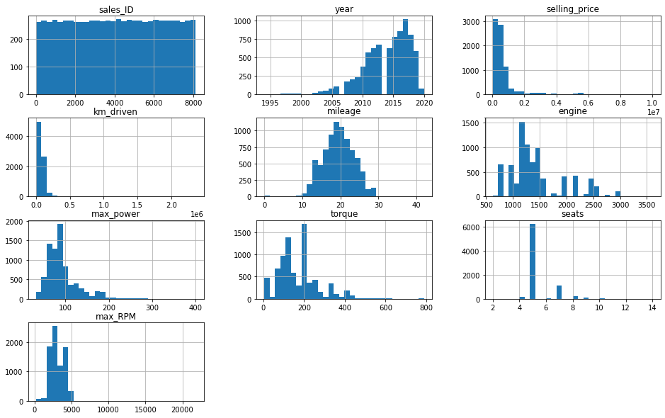

```python
# Plot the histogram of the different variables
df_clean.hist(bins= 30, figsize=(16, 10));
```

### Observation

> Among the distributions of the different attributes, the selling price and maximum power is happen to be right skewed and caught my interest. I will perform a scale transformation on the two variables, selling price and maximum power.

### What is the distribution of the selling prices of used cars?

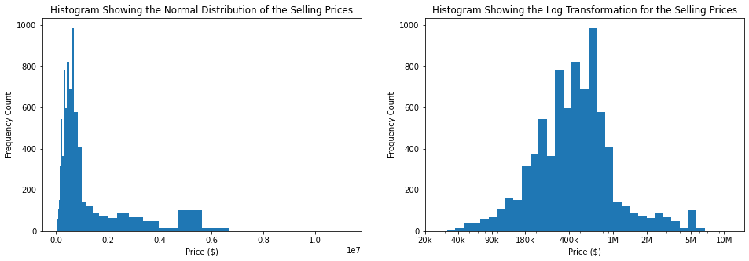

```python
# Resize the chart, and have two plots side-by-side
# set a larger figure size for subplots
plt.figure(figsize = [16, 5])

# histogram on left, 1 row, 2 cols, subplot 1
plt.subplot(1, 2, 1)# histogram on left, 1 row, 2 cols, subplot 1
log_binsize = 0.075
bins = 10 ** np.arange(4.5, np.log10(df_clean['selling_price'].max())+log_binsize, log_binsize)

plt.hist(data = df_clean, x = 'selling_price', bins = bins)
plt.title('Histogram Showing the Normal Distribution of the Selling Prices')
plt.ylabel('Frequency Count')
plt.xlabel('Price ($)');

# histogram on left, 1 row, 2 cols, subplot 2
plt.subplot(1, 2, 2)

# there's a long tail in the distribution, so let's put it on a log scale instead
log_binsize = 0.075
bins = 10 ** np.arange(4.5, np.log10(df_clean['selling_price'].max())+log_binsize, log_binsize)

plt.hist(data = df_clean, x = 'selling_price', bins = bins)
plt.title('Histogram Showing the Log Transformation for the Selling Prices')
plt.xscale('log')
plt.xticks([2e4, 4e4, 8e4, 16e4, 4e5, 1e6, 2e6, 5e6, 1e7], ['20k', '40k', '90k', '180k', '400k', '1M', '2M', '5M', '10M'])
plt.ylabel('Frequency Count')
plt.xlabel('Price ($)');
```

### Observation

> Our initial distribution of selling prices was unimodal so I did a log transformation on it to normalize it.

### What is the distribution of the maximum power of used cars?

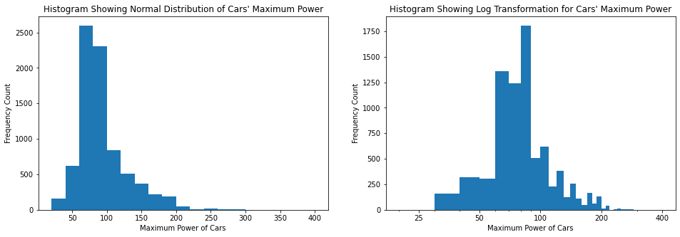

```python
# Resize the chart, and have two plots side-by-side
# set a larger figure size for subplots
plt.figure(figsize = [16, 5])

# histogram on left, 1 row, 2 cols, subplot 1
plt.subplot(1, 2, 1)

# Create bins with step-size 10
bins = np.arange(20, df_clean['max_power'].max()+20, 20)

# Set the labels of the plot
plt.xlabel('Maximum Power of Cars')
plt.ylabel('Frequency Count')
plt.title("Histogram Showing Normal Distribution of Cars' Maximum Power")

# Plot a histogram of the maximum power of the cars
plt.hist(df_clean['max_power'], bins = bins);


# histogram on right, 1 row, 2 cols, subplot 2
plt.subplot(1, 2, 2)

# Create bins with step-size 10
bins = np.arange(20, df_clean['max_power'].max()+10, 10)
plt.xscale('log')

# Set the labels of the plot
plt.xlabel('Maximum Power of Cars')
plt.ylabel('Frequency Count')
plt.xticks([2.5e1, 5e1, 1e2, 2e2, 4e2], ['25', '50', '100', '200', '400'])
plt.title("Histogram Showing Log Transformation for Cars' Maximum Power")

# Plot a histogram of the maximum power of the cars
plt.hist(df_clean['max_power'], bins = bins);
```

### Observation

> Our initial distribution of maximum power was right skewed so I did a log transformation on it to normalize it.

### What percentage of cars are sold and what percentage are left?

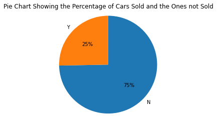

```python
# Set the value counts of the car transimission
sorted_counts = df_clean['sold'].value_counts()

# Set the title of the pie chart
plt.title('Pie Chart Showing the Percentage of Cars Sold and the Ones not Sold', pad= 5)

# Plot a pie chart showing the types of car transmission
plt.pie(sorted_counts, labels = sorted_counts.index, startangle = 90, counterclock = False, autopct='%.0f%%')
plt.axis('square');
```

### Observation

> The percentage of cars sold is 25% while the percentage of cars not sold is 75%. Only a quarter of the total cars are sold leaving the remaining fraction unsold.

### Which brands of cars are selling the most?

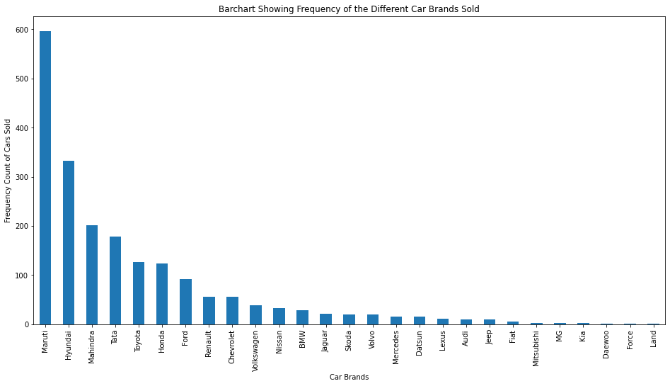

```python
# display the top 10 brands of cars that are in name column
sold_cars['name'].value_counts().plot.bar(figsize= (16, 8));

# Set the labels of the plot
plt.xlabel('Car Brands')
plt.ylabel('Frequency Count of Cars Sold')
plt.title('Barchart Showing Frequency of the Different Car Brands Sold');
```

### Observation

> Among the 27 brands that were sold, the brands that sells most is Maruti followed by Hyundai, Mahindra and Tata while Land had the least sales.

### What is the trend in the sales of used cars over the years?

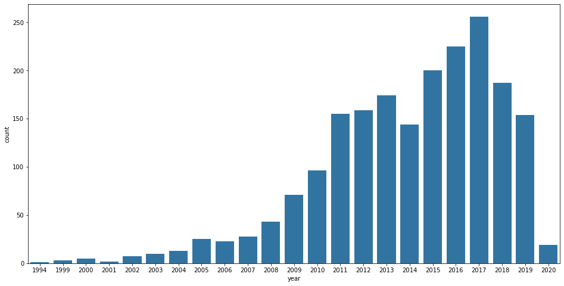

```python
plt.figure(figsize=(16,8))

base_color = sb.color_palette()[0]

# plot the frequency of used cars over the years
sb.countplot(x="year", data= sold_cars, color= base_color);
sold_cars.loc[:,'year'].value_counts();
```

### Observation

> From the year 1994 to the year 2020, it can be clearly seen that the year that recorded the most sales is 2017 followed by 2016 and 2015 with year 1994 having the least sales.

### Do certain regions record more sales than others?

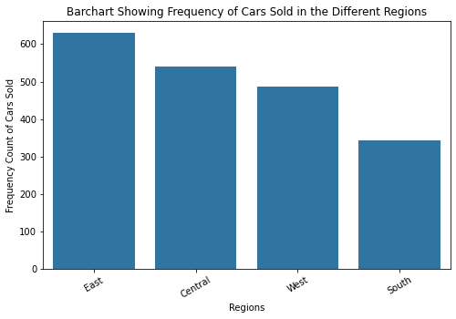

```python
plt.figure(figsize=(8,5))
base_color = sb.color_palette()[0]

# plot the frequency of used cars over the years
sb.countplot(x="region", data= sold_cars, color= base_color)

# Set the labels of the plot
plt.xlabel('Regions')
plt.ylabel('Frequency Count of Cars Sold')
plt.title('Barchart Showing Frequency of Cars Sold in the Different Regions')

# Use xticks to rotate the category labels (not axes) counter-clockwise
plt.xticks(rotation=30);
```

### Observation

> Among the four regions where the sales of used cars were recorded, the East region is seen to have the most sales and the South region having the least sales.

### What are the frequency of car sales made in the different states?

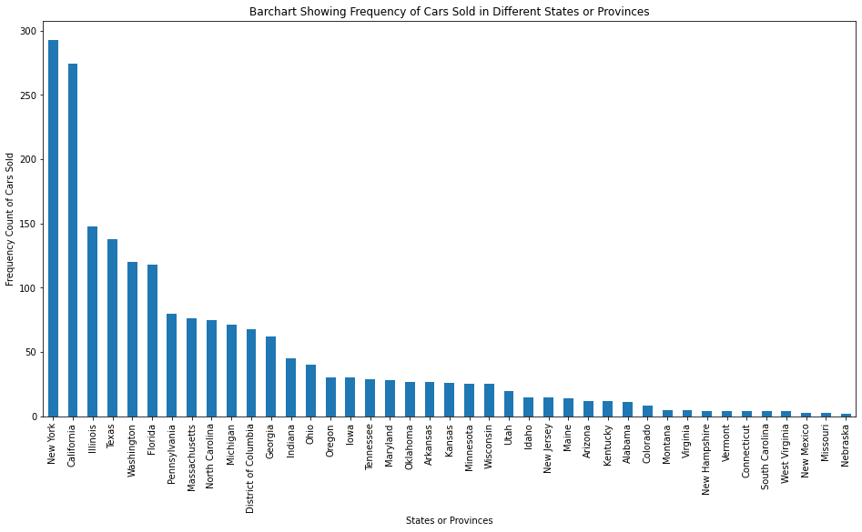

```python
plt.figure(figsize=(16,8))
base_color = sb.color_palette()[0]

# plot the frequency of used cars over the years
sold_cars['state'].value_counts().plot.bar(color= base_color)
# sb.countplot(x="state", data= sold_cars, color= base_color)

# Set the labels of the plot
plt.xlabel('States or Provinces')
plt.ylabel('Frequency Count of Cars Sold')
plt.title('Barchart Showing Frequency of Cars Sold in Different States or Provinces')

# Use xticks to rotate the category labels (not axes) counter-clockwise
plt.xticks(rotation=90);
```

### Observation

> Among the 49 states that were available in our dataset, New York happen to be the state that recorded the most sales of used cars followed by Carlifornia, Illinois and Texas while Nebraska happen to be the state with the least sales of used cars.

### Are there specific cities selling more?

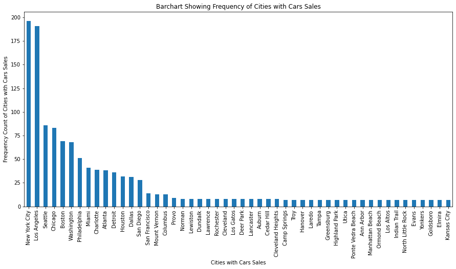

```python
# plot the value counts for the different cities
plt.figure(figsize=(15,7))
sold_cars['city'].value_counts()[:50].plot.bar()
plt.title('Barchart Showing Frequency of Cities with Cars Sales')
plt.xlabel('Cities with Cars Sales')
plt.ylabel('Frequency Count of Cities with Cars Sales')
plt.show();
```

### What kind of fuel does the cars that are selling more use?

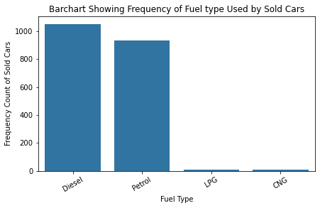

```python
# Plot a barchart of car ownership using seaborn
plt.figure(figsize=(7, 4))
base_color = sb.color_palette()[0]
sb.countplot(data = sold_cars, x = 'fuel', color = base_color)

# Set the labels of the plot
plt.xlabel('Fuel Type')
plt.ylabel('Frequency Count of Sold Cars')
plt.title('Barchart Showing Frequency of Fuel type Used by Sold Cars')

# Use xticks to rotate the category labels (not axes) counter-clockwise
plt.xticks(rotation=30);
```

### Observation

> The fuel type used by most cars sold is Diesel followed by Petrol and LPG with CNG being the fuel type used by the least cars sold.

### What are the percentage of the seller types of the sold cars?

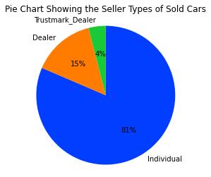

```python
# Set the value counts of the car transimission
sorted_counts = sold_cars['seller_type'].value_counts()

# Set the title of the pie chart
plt.title('Pie Chart Showing the Seller Types of Sold Cars', pad= 10)

# Set the color palette for the chart
colors = sb.color_palette("bright")

# Plot a pie chart showing the types of car transmission
plt.pie(sorted_counts, labels = sorted_counts.index, colors = colors, startangle = 90, counterclock = False, autopct='%.0f%%')
plt.axis('square');
```

### Observation

> The percentage for the type of sellers recorded with the most sales are Individuals having 81% followed by Dealers having 15% while Trustmark Dealers having 4% are the least on the list.

### What are the percentage of car transmission types on sold cars?

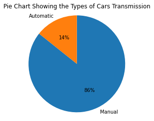

```python
# Set the value counts of the car transimission
sorted_counts = sold_cars['transmission'].value_counts()

# Set the title of the pie chart
plt.title('Pie Chart Showing the Types of Cars Transmission', pad= 5)

# Plot a pie chart showing the types of car transmission
plt.pie(sorted_counts, labels = sorted_counts.index, startangle = 90, counterclock = False, autopct='%.0f%%')
plt.axis('square');
```

### Observation

> Among the two type of transmission recorded, percentage for the type of transmission used by the cars with the most sales is Manual having 86% while cars with Automatic transmission having 14% has less sales.

### Which car owner type sells more?

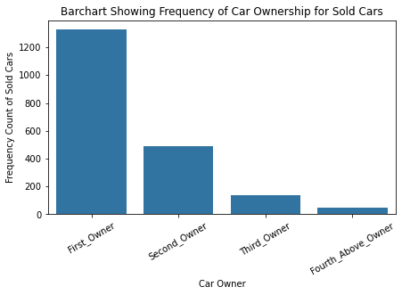

```python
# Plot a barchart of car ownership using seaborn
plt.figure(figsize=(7, 4))
base_color = sb.color_palette()[0]
sb.countplot(data = sold_cars, x = 'owner', color = base_color)

# Set the labels of the plot
plt.xlabel('Car Owner')
plt.ylabel('Frequency Count of Sold Cars')
plt.title('Barchart Showing Frequency of Car Ownership for Sold Cars')

# Use xticks to rotate the category labels (not axes) counter-clockwise
plt.xticks(rotation=30);
```

### Observation

> The cars that sells most were the ones with first owner. I guess this is due to the condition these cars are at such ownership level as compared to the second, third and fourth above ownership level.

### Discuss the distribution(s) of your variable(s) of interest. Were there any unusual points? Did you need to perform any transformations?

> The features of interest were the selling prices of cars and the variables that are significant in predicting the selling prices of cars happen to be maximum power, torque and engine. There were little unusual points in some of the variables but I did a scale transformation on the most significant ones.

### Of the features you investigated, were there any unusual distributions? Did you perform any operations on the data to tidy, adjust, or change the form of the data? If so, why did you do this?

> I did a log transformation on both the selling prices and the the maximum power of cars to normal them after discovering that the selling price had a unimodal distribution while the maximum power was right skewed.

## Bivariate Exploration

### Which variables are most significant in predicting the price of a used car?

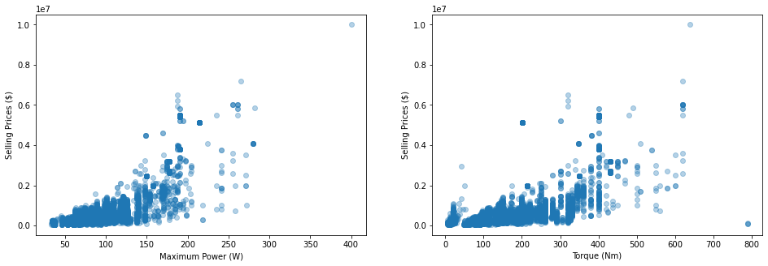

```python
# Resize the chart, and have two plots side-by-side
# set a larger figure size for subplots
plt.figure(figsize = [16, 5])

# histogram on left, 1 row, 2 cols, subplot 1
plt.subplot(1, 2, 1)

# Scatter plot
plt.scatter(data = df_clean, x = 'max_power', y = 'selling_price', alpha = 1/3);

# set labels
plt.xlabel('Maximum Power (W)')
plt.ylabel('Selling Prices ($)');

# histogram on right, 1 row, 3 cols, subplot 2
plt.subplot(1, 2, 2)

# Scatter plot
plt.scatter(data = df_clean, x = 'torque', y = 'selling_price', alpha = 1/3);

# set labels
plt.xlabel('Torque (Nm)')
plt.ylabel('Selling Prices ($)');
```

### Which variables are more significant in predicting the price of a used car?

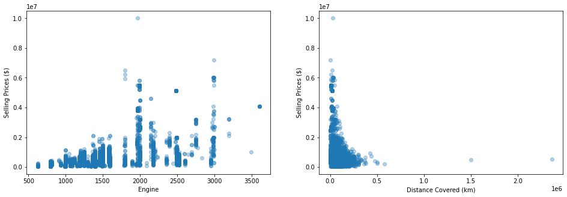

```python
# Resize the chart, and have two plots side-by-side
# set a larger figure size for subplots
plt.figure(figsize = [16, 5])

# histogram on right, 1 row, 2 cols, subplot 2
plt.subplot(1, 2, 1)

# Scatter plot
plt.scatter(data = df_clean, x = 'engine', y = 'selling_price', alpha = 1/3);

# set labels
plt.xlabel('Engine')
plt.ylabel('Selling Prices ($)');

# histogram on right, 1 row, 2 cols, subplot 2
plt.subplot(1, 2, 2)

# Plot scatter plot of torque against maximum power
plt.scatter(data = df_clean, x = 'km_driven', y = 'selling_price', alpha = 1/3)

# set labels
plt.xlabel('Distance Covered (km)')
plt.ylabel('Selling Prices ($)');
```

### Observation

> The engine of the cars helps the maximum power and the torque to build a strong correlation with the selling prices as it increases with respect to increase in the selling prices while the lesser the distance covered by the used cars the higher their selling prices.

### Does vehicle ownership affect the selling prices of used cars?

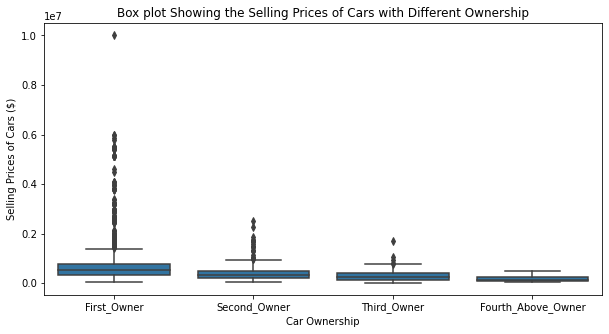

```python
plt.figure(figsize = [10, 5])
owner_classes = ['First_Owner', 'Second_Owner', 'Third_Owner', 'Fourth_Above_Owner', 'Test_Drive_Car']

car_classes = pd.api.types.CategoricalDtype(ordered = True, categories = owner_classes)
df_clean['owner'] = df_clean['owner'].astype(car_classes)

# plotting
base_color = sb.color_palette()[0]
sb.boxplot(data = sold_cars, x = 'owner', y = 'selling_price',
                color = base_color)

# Set the labels of the plot
plt.xlabel('Car Ownership')
plt.ylabel('Selling Prices of Cars ($)')
plt.title('Box plot Showing the Selling Prices of Cars with Different Ownership')
plt.xticks();
```

### Observation

> The average selling prices of cars sold from first owners are higher as compared to the other levels of ownership. I guess the prices are high since they are in a good condition and may not really give the buyers much trouble.

### What is the frequency of cars sold with respect to their type of transmission and fuel used?

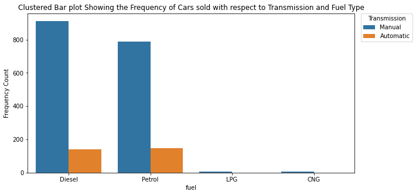

```python
plt.figure(figsize=(10,5))
sb.countplot(data = sold_cars, x = 'fuel', hue = 'transmission');
plt.ylabel('Frequency Count')
plt.title('Clustered Bar plot Showing the Frequency of Cars sold with respect to Transmission and Fuel Type')
plt.legend(bbox_to_anchor=(1.02, 1), loc='upper left', borderaxespad=0, title='Transmission');
```

### Observation

> Cars that use diesel as their fuel with manual transmission sell more than cars that use petrol as fuel with manual tranmission whereas the ones using diesel with automatic and the ones using petrol with automatic seems to sell at the same rate.

### Does the fuel types used affect the selling prices of the used cars?

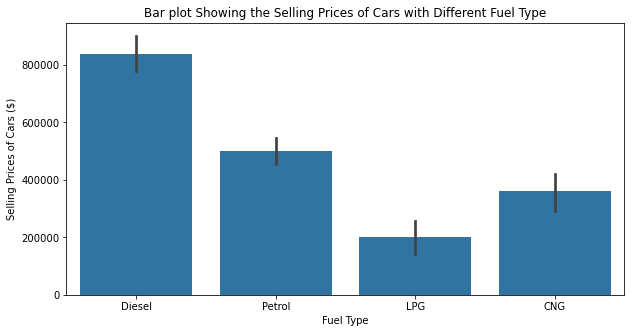

```python
plt.figure(figsize = [10, 5])
fuelType_classes = ['Diesel', 'Petrol', 'CNG', 'LPG']

fuel_classes = pd.api.types.CategoricalDtype(ordered = True, categories = fuelType_classes)
df_clean['fuel'] = df_clean['fuel'].astype(fuel_classes)

# plotting
base_color = sb.color_palette()[0]
sb.barplot(data = sold_cars, x = 'fuel', y = 'selling_price',
                color = base_color)

# Set the labels of the plot
plt.xlabel('Fuel Type')
plt.ylabel('Selling Prices of Cars ($)')
plt.title('Bar plot Showing the Selling Prices of Cars with Different Fuel Type')
plt.xticks();
```

### Observation

> The average selling prices of cars using diesel is higher as compared to the other fuel types. This implies that cars running on diesel are more expensive that those using petrol, CNG and LPG.

### What are the trends in the selling prices of cars sold over the years?

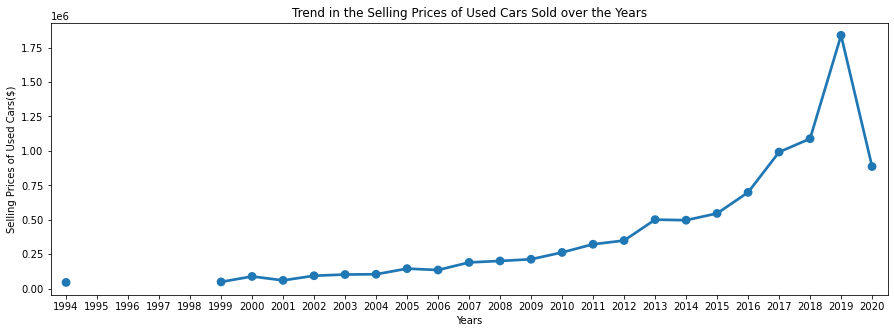

```python
plt.figure(figsize=(15,5))
sb.pointplot(data=sold_cars, x='year', y='selling_price', order=np.arange(1994,2021,1), ci=0, dodge=True)
plt.title('Trend in the Selling Prices of Used Cars Sold over the Years')
plt.xlabel('Years')
plt.ylabel('Selling Prices of Used Cars($)')
plt.show();
```

### Observation

> The average selling prices of cars sold over the years increases gradually with its peak in the year 2019. No sales of cars was recorded from 1995 to 1998.

### Talk about some of the relationships you observed in this part of the investigation. How did the feature(s) of interest vary with other features in the dataset?

> From my exploration, the greater the maximum power and torque and engine of the cars, the higher their selling prices.

### Did you observe any interesting relationships between the other features (not the main feature(s) of interest)?

> Cars that sells more run on either diesel or petrol and they are mostly of the manual transmission type having first owner and sold by individuals.

## Multivariate Exploration

### What are the trends in the selling prices of cars sold over the years across regions?

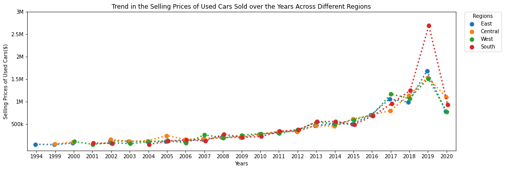

```python
plt.figure(figsize=(15,5))
sb.pointplot(data=sold_cars, x='year', y='selling_price', hue='region', linestyles=':', ci=0, dodge=True)
plt.title('Trend in the Selling Prices of Used Cars Sold over the Years Across Different Regions')
plt.xlabel('Years')
plt.ylabel('Selling Prices of Used Cars($)')
plt.yticks([5e5, 1e6, 1.5e6, 2e6, 2.5e6, 3e6], ['500k', '1M', '1.5M', '2M', '2.5M', '3M']);
plt.legend(bbox_to_anchor=(1.02, 1), loc='upper left', borderaxespad=0, title='Regions');
```

### What is the average selling prices for sold cars with regards to their transmission and fuel type?

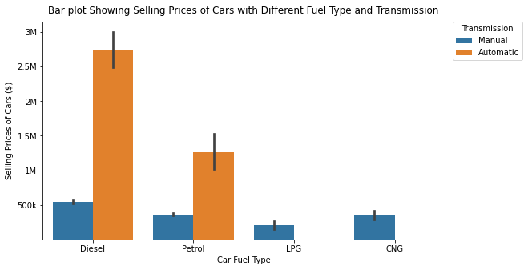

```python
plt.figure(figsize=(9,5))
sb.barplot(data = sold_cars, x = 'fuel', y= 'selling_price', hue = 'transmission');
plt.xlabel('Car Fuel Type')
plt.ylabel('Selling Prices of Cars ($)')
plt.title('Bar plot Showing Selling Prices of Cars with Different Fuel Type and Transmission', pad=10)
plt.yticks([5e5, 1e6, 1.5e6, 2e6, 2.5e6, 3e6], ['500k', '1M', '1.5M', '2M', '2.5M', '3M']);
plt.legend(bbox_to_anchor=(1.02, 1), loc='upper left', borderaxespad=0, title='Transmission');
```

### Observation

> The average selling prices of sold cars with regards to the transmission and fuel type shows that cars that run on diesel with automatic transmission are very expensive, followed by the one running on petrol with automatic transmision leaving the ones with manual transmission trailing behind on the list.

### Which are the correlation between the different variables?

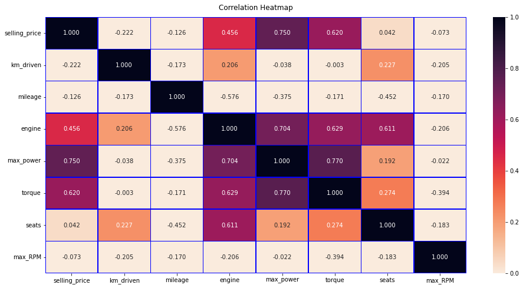

```python
# Visualization of correlation results with seaborn library heatmap.
f,ax=plt.subplots(figsize=(16,8))

heatmap = sb.heatmap(car_variables.corr(), annot=True, linewidths=0.5, linecolor="blue", cmap="rocket_r", fmt=".3f", vmin=0, ax=ax)
heatmap.set_title('Correlation Heatmap', fontdict={'fontsize':12}, pad=12);
plt.show();
```

### Observation

> From the above heatmap, there is a strong correlation between maximum power, torque, engine of cars with the selling prices of cars and a strong correlation between maximum power, torque and seats of cars with the engine of cars.

### Which variables are significant in predicting the price of a used car?

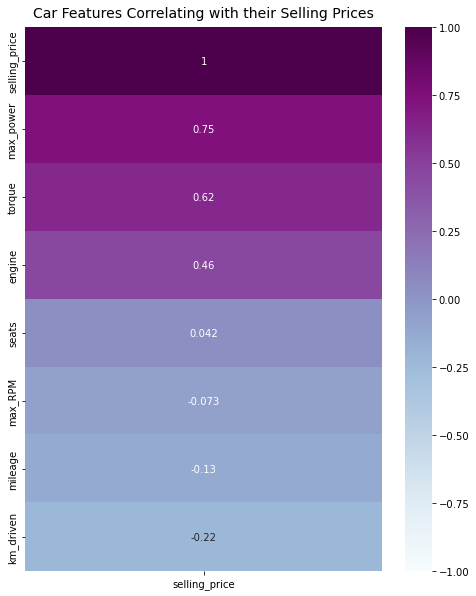

```python
plt.figure(figsize=(8, 10))
heatmap = sb.heatmap(car_variables.corr()[['selling_price']].sort_values(by='selling_price', ascending=False), vmin=-1, vmax=1, annot=True, cmap='BuPu')
heatmap.set_title("Car Features Correlating with their Selling Prices", fontdict={'fontsize':14}, pad=10);
```

### Observation

> From the above heatmap, The variables that are significant in predicting the selling prices of cars are maximum power, torque and engine.

### Talk about some of the relationships you observed in this part of the investigation. Were there features that strengthened each other in terms of looking at your feature(s) of interest?

> The variables that are most significant in determining the selling prices of cars are the maximum power followed by the torque and the feature that help strengthen their relationship is the engine. The cars that sells more had manual transmission and uses diesel and petrol as their fuel, was in the first car owner category, were sold by individuals and the feature that help strengthen their relationship are the locations where the sales were made.

### Were there any interesting or surprising interactions between features?

> The interesting interactions is the relationship between the maximum power and torque with the selling prices and the engine helped in strengthening this relationship.

## Conclusions

> My features of interest are the selling prices of cars and the variables that are significant in predicting the prices of cars are maximum power, torque and engine. There were little unusual points in some of the variables but I did a log transformation on my most significant features of interest, selling price and the maximum power to normalise them since I discovered in my exploration that they were both right skewed.

> From my exploration, the greater the maximum power, torque and engine of the cars, the higher their selling prices. Cars that sells more run on either diesel or petrol and they are mostly of the manual transmission type having first owner as their owner type and being sold by individuals. The locations where these sales were made which includes the regions, states and cities helps to strengthen their relationship between the car features and the total number of sales made.